# Analyser le marché immobilier sous R

FChemin

30/01/2017

## Introduction

S’installer dans une nouvelle ville commence bien souvent par la recherche d’un logement. Cependant, obtenir une vue d’ensemble du marché locatif n’est pas une mince affaire: comment savoir que le loyer proposé n’est pas surcoté ? Quel est le loyer moyen pour un appartement de 75m² avec 2 chambres ? Nous allons voir ici comment récupérer ces informations à partir d’Internet et les analyser à l’aide du langage de programmation R.

Cet article sera divisé en trois parties: récupérer les données, nettoyer ces données et enfin, les analyser. Dans la première partie, nous créerons un outil afin de collecter les données issues de sites web (web scraper). Dans la seconde partie, nous formaterons les données afin qu’elles puissent être aisément manipulées. Enfin, dans la troisième partie, nous analyserons et visualiserons ces données afin de se faire une idée du marché locatif.

## Web scraping

Lorsque nous n’avons pas de données déjà disponibles, il nous faut les récupérer à l’aide d’un web scraper, autrement dit, quelques lignes de code qui vont télécharger les pages web d’annonces de logement à louer, récupérer les données et les enregistrer dans un fichier CSV (par exemple) automatiquement pour nous.

#### Un peu de planification

La première chose à faire est de déterminer les informations dont nous avons besoin. Ici, nous voulons cibler les logements en location pour la ville de Brest, France. Pour se faire une idée du marché locatif, nous aurons besoin des informations suivantes:

- le montant du loyer
- le type de location
- le nombre de pièces du logement
- la superficie du logement

## Du côté du HTML

Nous voulons que notre outil récupère automatiquement les informations contenues dans la page web d’une annonce. Pour se faire, il nous faut inspecter le code HTML d’une page web:

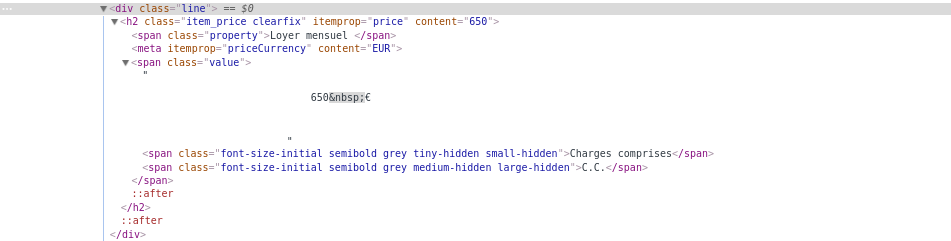

Sur cette image nous pouvons voir où est stockée la valeur concernant le loyer.

Une extension particulièrement utile pour les utilisateurs de Chrome souhaitant récupérer les sélecteurs CSS d’une page web s’appelle [SelectorGadget](http://selectorgadget.com/). Nous en ferons usage lorsque nous détaillerons la création de notre web scraper.

## Librairies utilisées

Pour ce projet, nous faisons appel aux librairies suivantes:

```r
library(rvest)
library(magrittr)
library(stringr)
library(dplyr)
library(plotly)
```

**rvest**

Nous utiliserons ce paquet pour télécharger, lire et récupérer le contenu d’une page web.

**magrittr**

Ce paquet permet d’améliorer la lecture et la maintenance de notre code à l’aide de l’opérateur spécial %>%.

**stringr**

Stringr facilite les opérations sur les chaînes de caractères.

**plotly**

Ce sera notre outil de choix pour la création de nos visualisations intéractives.

## Écriture du code

La première étape de l’écriture de notre code consistera à créer deux nouvelles fonctions. La première fonction va nous permettre de récupérer les liens des annonces comprises dans un résultat de recherche:

```r
get_ads_links = function(zipcode){

    url_base <- "https://www.sitekelonvescrap.fr/locations/offres/bretagne/"

    result <- NULL

    page <- url_base %>% paste("?o=", 1, "&zz=", zipcode, sep = "") %>%
        read_html()

    tags <- "//section/ul/li/a[contains(@href, 'locations')]"

    ad_links <- page %>% html_nodes(xpath = tags) %>%
        html_attr("href")
    ad_links <- paste("https:", ad_links, sep = "")

    result <- c(result, ad_links)

    result <- data.frame(result, stringsAsFactors = FALSE)

    write.csv(result, file = "links.csv", row.names = FALSE)

    return(result)

}
```

La seconde fonction consiste à récupérer les informations qui nous intéressent dans chacune des annonces:

```r
get_ads_details = function(url){

    result <- NULL

    page <- read_html(url[1,])

    cost <- page %>% html_node(css = ".item_price .value") %>%
        html_text()

    category <- page %>% html_node(css = ".line_city+ .line .value") %>%
        html_text()

    rooms <- page %>% html_node(css = ".line:nth-child(8) .value") %>%
        html_text()

    area <- page %>% html_node(css = ".line:nth-child(10) .value") %>%
        html_text()

    result <- rbind(result,c(cost, category, rooms, area, url[1,]))

    df <- data.frame(result, stringsAsFactors = FALSE)
    names(df) <- c("Monthly Rent", "Category", "Number of Rooms", "Area", "URL")

    write.csv(df, file = "rental_market.csv", row.names = FALSE)

    return(df)
}
```

## Notre web scraper à l’usage

Maintenant que nous avons créer les fonctions nécessaires à notre outil, nous pouvons l’utiliser pour débuter notre travail d’analyse:

```r
liens <- get_ads_links(zipcode = 29200)
df <- get_ads_details(liens)
```

Nous obtenons alors une trame de données que nous pouvons aisément manipuler.

```r
str(df)
```

[output not shown]

```r
head(df, 3)
```

[output not shown]

Nous avons du nettoyage à faire avant de pouvoir analyser ces données !

## Ne garder que le nécessaire

La recherche de locations retourne plusieurs types de biens: appartement, maison, terrain ou encore parking. Nous souhaitons ne conserver que les informations concernant des appartements et des maisons. Ensuite, il nous faut isoler les nombres des valeurs concernant le montant du loyer et la surface de l’habitation. Puis, nous transformons les variables concernant le type d’habitation en facteurs et enfin, nous supprimons les lignes de notre trame de données ayant des informations manquantes (NAs). Voici le code utilisé pour cette partie:

```r
df <- subset(df, df$Category %in% c("Appartement", "Maison"), drop = TRUE)

df$Monthly.Rent <- gsub(" ", "", df$Monthly.Rent)
expr <- "[[:digit:]]+"
df$Monthly.Rent <- df$Monthly.Rent %>% str_extract(expr) %>% as.integer()

df$Area <- df$Area %>% str_extract(expr) %>% as.integer()

df$Category <- as.factor(gsub("Appartement", 1, df$Category))
df$Category <- as.factor(gsub("Maison", 2, df$Category))
df$Number.of.Rooms <- as.integer(df$Number.of.Rooms)

df <- df[complete.cases(df),]
rownames(df) <- NULL

head(df, 5)
```

```
##   Monthly.Rent Category Number.of.Rooms Area
## 1          560        1               4   76
## 2          325        1               1   20
## 3          395        1               2   35
## 4          490        1               2   52
## 5          385        1               1   22
```

C’est bien mieux ainsi ! Nous pouvons maintenant commencer à manipuler nos données afin de les analyser et mieux les comprendre.

## Exploration des données

Commençons par regarder le sommaire de nos données:

```r
summary(df)
```

```
##   Monthly.Rent    Category Number.of.Rooms       Area
##  Min.   :  10.0   1:1134   Min.   : 1.000   Min.   :  10.00
##  1st Qu.: 395.0   2:  67   1st Qu.: 2.000   1st Qu.:  36.00
##  Median : 486.0            Median : 3.000   Median :  54.00
##  Mean   : 495.6            Mean   : 2.719   Mean   :  69.65
##  3rd Qu.: 566.0            3rd Qu.: 3.000   3rd Qu.:  69.00
##  Max.   :1300.0            Max.   :22.000   Max.   :3668.00
```

Il semblerait que certaines valeurs concernant le nombre de pièces (22, vraiment ?!), le montant du loyer (10€, autant dire gratuit !) ou encore la superficie (3668m²…) soient erronnées. Regardons de plus près quelles lignes sont concernées et ce que nous pouvons en faire:

```r
df[which(df$Monthly.Rent == 10),]
```

```
##     Monthly.Rent Category Number.of.Rooms Area
## 636           10        2               7  140
```

```r
df[which(df$Number.of.Rooms == 22),]
```

```
##     Monthly.Rent Category Number.of.Rooms Area
## 563          350        1              22   22
```

```r
df[which(df$Area > 200),]
```

```
##      Monthly.Rent Category Number.of.Rooms Area
## 31            680        1               3 3492
## 134           800        2               4  268
## 142           780        2               5 1485
## 252           300        2              10  350
## 325           640        1               4  434
## 388           458        1               2 3643
## 559           300        1               2 3627
## 861           315        1               1  433
## 977           250        1               1  237
## 1030          400        1               2 1390
## 1098          620        1               3 3668
```

Concernant la location au loyer de 10€, pour une maison avec 7 chambres et 140m², il s’agit soit d’une erreur ou bien d’une stratégie pour attirer du monde sur l’annonce. Nous ne conserverons donc pas cette ligne:

```r
df <- df[-which(df$Monthly.Rent == 10),]
rownames(df) <- NULL
```

Pour la location de 22m² avec 22 pièces, cela ressemble à une erreur lors de la saisie du formulaire pour créer l’annonce. Étant donnée la surface, nous faisons le choix de considérer qu’il s’agit d’un studio et donc, d’une seule pièce:

```r
df$Number.of.Rooms[563] <- 1
```

Concernant les superficies, nous préférons supprimer les entrées ayant une superficie supérieure à 200m². Ceci nous semble être un choix raisonnable afin de ne pas fausser notre analyse avec des cas particuliers (outliers):

```r
df <- df[-which(df$Area > 200),]
rownames(df) <- NULL
```

Regardons une dernière fois notre sommaire:

```r
summary(df)
```

```
##   Monthly.Rent    Category Number.of.Rooms      Area
##  Min.   :  90.0   1:1126   Min.   :1.000   Min.   : 10.00
##  1st Qu.: 395.0   2:  63   1st Qu.:2.000   1st Qu.: 35.00
##  Median : 486.0            Median :3.000   Median : 53.00
##  Mean   : 495.9            Mean   :2.692   Mean   : 54.24
##  3rd Qu.: 565.0            3rd Qu.:3.000   3rd Qu.: 68.00
##  Max.   :1300.0            Max.   :8.000   Max.   :191.00
```

Cette fois-ci, la distribution dans chaque catégorie nous semble beaucoup plus réaliste et nous pouvons faire quelques observations.

Regardons pour commencer l’offre de locations d’appartement:

```r
prop_apt <- round(sum(df$Category == 1)/nrow(df)*100 , 0)

df_apt <- subset(df, df$Category == 1, drop = TRUE)

range(df_apt$Monthly.Rent)
median(df_apt$Monthly.Rent)

range(df_apt$Area)
median(df_apt$Area)
```

[output not shown]

95% des annonces de location concernent des appartements. Le loyer commence à 90€ avec un maximum de 1300€ pour un **loyer median de 480€**. La surface médiane quant à elle est de **51m²**.

## Quelques visualisations

Pour commencer, regardons la distribution du nombre de pièces selon le type de location:

[interactive chart not shown]

Le même graphique mais cette fois-ci pour les maisons:

[interactive chart not shown]

Enfin, un graphique à trois dimensions comparant le loyer des locations selon leur superficie et le nombre de pièces qu’elles comprennent. Ce graphique est intéractif, n’hésitez pas à zoomer sur une zone qui vous intéresse ou passer votre souris sur un des points pour obtenir le détail de ses valeurs:

[interactive chart not shown]

## Conclusion

Nous avons vu dans cet article comment obtenir des données lorsque nous n’en avons pas à notre disposition, les nettoyer, les explorer et créer des visuels afin de s’en faire une meilleure idée.

Ceci peut servir de base à un travail de recherche sur l’évolution des loyers, en datant chaque entrée de notre base de données afin de pouvoir faire une analyse de séries temporelles. Nous pourrions également nous servire de cette base de données pour modéliser le prix d’un loyer selon les caractéristiques du logement.